# Chapter17_Parametric_non_tests

Setting up a fancy stylesheet

```python
from IPython.core.display import HTML
css_file = 'style.css'
HTML(open(css_file, 'r').read())
```

Setting up the required python ™ environment

```python
import numpy as np
#import pandas as pd
from scipy import stats
#from scipy.stats import bayes_mvs
#from math import factorial
#import scikits.bootstrap as bs
import matplotlib.pyplot as plt
import seaborn as sns
from warnings import filterwarnings

%matplotlib inline
sns.set_style('dark')
sns.set_context('paper', font_scale = 2.0, rc = {'lines.linewidth': 1.5, 'figure.figsize' : (10, 8)})
filterwarnings('ignore')
np.random.seed(123)
```

# Parametric vs non-parametric statistical tests

## Introduction

Before, I mentioned that a histogram of the mean of all possible means will be normally distributed. Actually things are a bit more complicated than that. No surprise! In the grander scheme of things, there are two types of statistical tests, called parametric and non-parametric tests. These two groups exist, because using the appropriate type of test for an appropriate setting allows for more accurate anlaysis and a more proper representation of what we are trying to achieve (infering statistics on population parameters).

## The QQ plot

A parametric test is used when the sample data is taken from a normal distribution and a non-parametric test if it is not. Wow! We only have our sample data. How can we know this? Well, there's the probability plot from the *scipy.stats* library. It is more commonly known as the QQ-plot. It plots every data point against its quartile on a Cartesian plane. It then gives you a visual representation of how correlated these are. If they are not, the data is not from a normal distribution and you have to use a non-parametric test.

First, I'll generate 40 random values from the normal distribution, and constrain it to a mean of 100 and a standand deviation of 20.

```python
rv1_values = stats.norm.rvs(loc = 100, scale = 20, size = 40)
```

Now let's do the QQ plot

The *stats.probplot()* function takes three arguments. The first is the acutal data values, the second teels the software to compare our values to normal distribution. If I wanted to see if my valuyes fit some other distribution I could have used something other than 'norm' and lastly we plot.

The plot will state a R<sup>2</sup> value. A value of 1.0 means an absolute fit and 0.0 means no fit (i.e. realy, really not from a normal distribution.

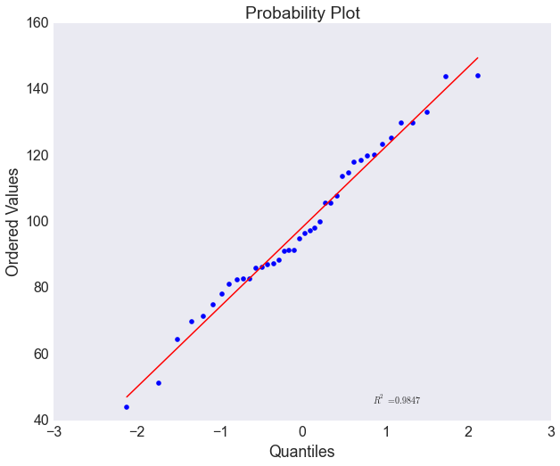

```python
plt.figure(figsize = (10,8))
stats.probplot(rv1_values, dist="norm", plot=plt) #
plt.show();
```

Now I'll generate 40 values from anotehr type of continuous random distribution called the exponential distribution and see how it compares.

```python
rv2_values = stats.expon.rvs(size = 40)
```

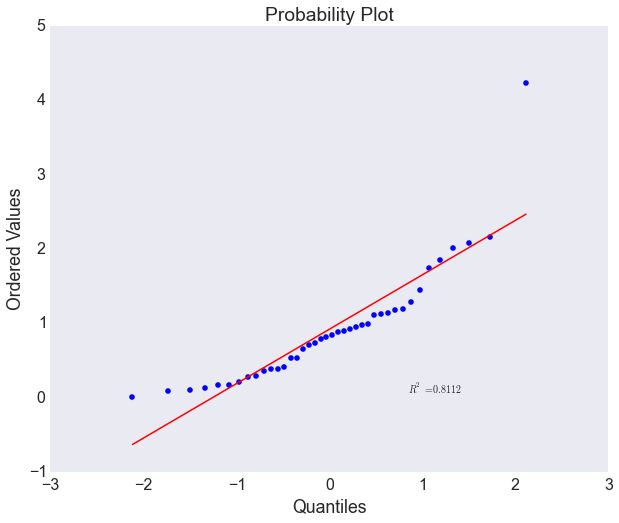

```python
stats.probplot(rv2_values, dist="norm", plot=plt);
```

## Tests for numerical data

The quintessential parametric test for ratio, numerical data is Student's t-test.

An example of a non-parametric t-test is the Mann-Whitney-Wilcoxon rank sums test